# Millenials Kill Everything: Proof of Concept

# Introduction

This analysis is a proof-of-concept for an article on industries/products Millenials have killed. I’ll provide a high-level concept for both pieces of the article outlined in my plan:

1. Web scraping for relevant articles
2. Using administrative data to establish spending trends by age group

# Web Scraping

To get an idea of what news outlets are saying about Millenial purchasing patterns, I ran a web scraper that pulls the results of a very simple Google search: “millenials kill”. Future searches will need to be more complex to capture a wider array of articles, but I think the results of this query are sufficient for now. I set the number of search results to 99 (the query can return less than 100) and filter articles that explicity mention a collection of things (lists, businesses, industries, etc). These articles are most likely to be in a “listicle” format and thus will be easier to parse because the items of interest will be demarcated with a consistent HTML tag (header classes).

Some of these articles are in a slideshow format, and this code isn’t complex enough to parse those. Future explorations should identify when an article is a slideshow and index through slides. This code should also be expanded to capture items mentioned in the body text of an article; I imagine such an exercise would requre a method that identifies objects in text, such as Named Entity Recognition.

Below is the chunk of R code that scrapes the web and displays a table of results.

```r
 library(rvest); library(stringr)

results <- read_html("https://www.google.com/search?q=millenials+kill&num=100")
results <- results %>%
  html_nodes(".r a") %>%
  html_attr("href")

results <- gsub('/url\\?q=','',sapply(strsplit(results[as.vector(grep('url',results))],split='&'),'[',1))

results <- results[grep("things|-list-|industries|businesses|products", results)]

things <- c()
for (link in results) {
  article <- read_html(link)
  article <- article %>%
    html_nodes("body") %>%
    html_nodes("h2") %>%
    html_text()
  article <-  gsub("\\n+\\s+|\\d\\.|:|\\d(\\s)+", "", article)
  article <- gsub("^\\s+|^\\d", "", article)
  things <- append(things, article)
}

things <- things[!duplicated(things)]
data.frame(Items = things)
```

| Items |
| --- |
| Casual dining chains like Buffalo Wild Wings and Applebee's |
| The concept of "starter homes" — they're renting longer and buying expensive houses later |
| Beer |
| Napkins |
| "Breastaurant" chains like Hooters |
| Cereal |
| Golf |
| Motorcycles |
| Homeownership |
| Yogurt — especially light yogurt |

[output cut: 97 more lines]

This method gives us a nice list, but as we can see, there’s a lot of junk in here that would be difficult to clean using regular expressions. I’ve got a little over 100 items total. Because this list is so short, it’ll be faster for me to manually remove all the irrelevant items and load the data back in.

```r
write.csv(things, "items.csv", row.names = F)
items <- read.csv("items_cleaned.csv")
names(items) <- "Items"
items
```

| Items |
| --- |
| Casual dining chains like Buffalo Wild Wings and Applebee's |
| The concept of "starter homes" — they're renting longer and buying expensive houses later |
| Beer |
| Napkins |
| "Breastaurant" chains like Hooters |
| Cereal |
| Golf |
| Motorcycles |
| Homeownership |
| Yogurt — especially light yogurt |

[output cut: 43 more lines]

Now we’ve got a nice table of a little over 50 items that the media says Millenials have brutally murdered over the last year. It looks like the items span multiple categories, from food to retail to leisure activities. These items appear to mostly be non-essential goods; I’m not seeing things like meat or milk or Internet subscriptions on the list. A more robust way of identifying common threads would be mapping each of these items to an industry, possibly a [NAICS industry code](https://www.naics.com/business-lists/counts-by-naics-code/?#countsByNAICS).

# Analysis of administrative data

I have a background in economics, and the Consumer Expenditure Survey (CES) was the first data that came to mind when I saw this article idea. The CES is the Bureau of Labor Statistics’ (BLS) annual comprehensive survey of American purchasing patterns. The BLS offers microdata and aggregated data from the CES. I use aggregated data for this analysis, and pulled the data using the BLS [Data Finder](https://www.bls.gov/bls/dqt_feature.htm). I downloaded data extracts on average spending by age group for three industries Millenials are puportedly not fond of:

1. Cereal [(yes, really)](https://www.washingtonpost.com/news/wonk/wp/2016/02/23/this-is-the-height-of-laziness/?noredirect=on&utm_term=.4eb0742f1166)
2. New vehicles (including cars and trucks)
3. Housing (as measured by spendng on mortgage-related interest and costs)

I also chose these categories because the BLS already has summary statistics for them. If I wanted to look at products that aren’t within their [pre-defined groups](https://beta.bls.gov/dataQuery/find?fq=survey:%5Bcx%5D&s=popularity:D), I would need to use the microdata. I analyze average yearly expenditures in each category by age group. I believe these data provide a good introductory look at our question, and will enable us to answer a few basic questions:

1. Is Millenial spending in these areas actually declining over time?
2. How does spending in these industries vary by age group (are Millenials single-handedly killing the cereal industry, or are other generations also doing their part?)

For each category, I plot a time series chart of average expenditures by year and age group. The data cover 2007-2017. I plot the trends by age group. There isn’t a perfect match between the age groups in the summary data and generational age bands, but I generally treat individuals aged 25-34 as Millenials, individuals aged 35-44 as Generation X, and individuals aged 45-54 as Boomers. If I used the microdata, I could create more accurate generation categories.

```r
library(dplyr); library(ggplot2)
file.path <- paste0(getwd(), "/data")
all.extracts <- data.frame(Year = NA, Value = NA, Series.ID= NA, Age.Group = NA)

for (file in list.files(path = file.path) ) {
  temp.file <- read.csv(paste(file.path, file, sep = "/"))
  temp.file <- temp.file[,c("Year", "Value", "Series.ID")]
  if (length(grep("millenial", file)) > 0) {
    temp.file$Age.Group <- "Aged 25-34"
  } else if (length(grep("genx", file)) > 0) {
    temp.file$Age.Group <- "Aged 35-44"
  } else if ( length(grep("boomer", file)) > 0) {
    temp.file$Age.Group <- "Aged 45-54"
  }
  all.extracts <- rbind(all.extracts, temp.file)
}

rm(temp.file)

calc.pct.change <- function(x) {x / lag(x) - 1}
```

## Cereal

```r
cereal <- all.extracts[grepl("CEREAL", all.extracts$Series.ID),]
cereal <- cereal %>%
  group_by(Age.Group) %>%
  mutate(Percentage.Change = calc.pct.change(Value))
```

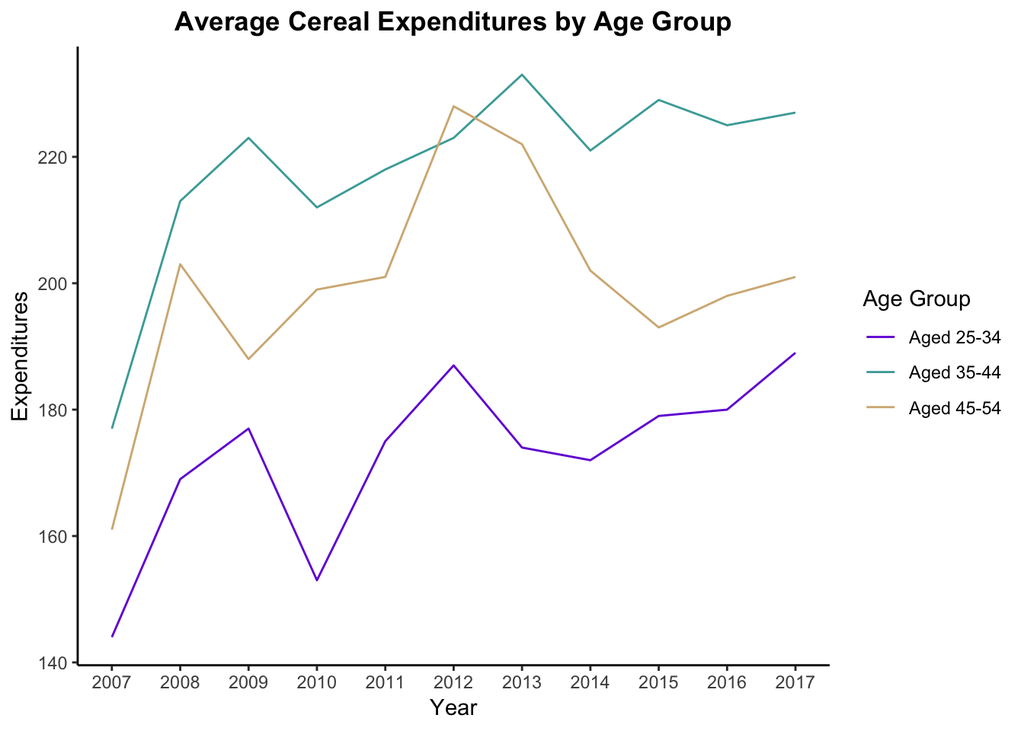

```r
ggplot(cereal) +
  geom_line(aes(x = Year, y = Value, colour = Age.Group)) +
  theme_classic() + scale_x_continuous(breaks = 2007:2017, labels = unique(cereal$Year)) +
  scale_colour_manual(name = "Age Group", values = c("#731DD8","#48A9A6","#D4B483")) +
  labs(title = "Average Cereal Expenditures by Age Group", x = "Year", y = "Expenditures") +
  theme(plot.title = element_text(hjust = 0.5, face = "bold"))
```

As predicted, Millenials have always spent less on cereal than other age groups. Millenials saw the largest drop in cereal purchases between 2009 and 2010. However, average cereal expenditures is increasing among all age groups for most of the past decade. The oldest age group (45-54) saw declining cereal purchases starting in 2012, and the decline was pretty consistent until 2015. Generation X has the highest average cereal purchases in this time period, and that makes sense because they’re the most likely group to have kids. Every age group saw a spike in average expenditures from 2016-2017.

## New vehicles

```r
vehicles <- all.extracts[grepl("CAR", all.extracts$Series.ID),]
vehicles <- vehicles %>%
  group_by(Age.Group) %>%
  mutate(Percentage.Change = calc.pct.change(Value))
```

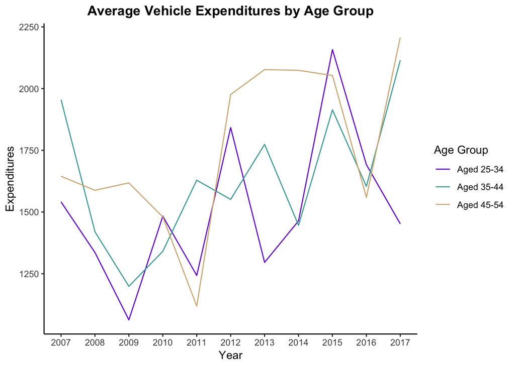

```r
ggplot(vehicles) +
  geom_line(aes(x = Year, y = Value, colour = Age.Group)) +
  theme_classic() + scale_x_continuous(breaks = 2007:2017, labels = unique(vehicles$Year)) +
  scale_colour_manual(name = "Age Group", values = c("#731DD8","#48A9A6","#D4B483")) +
  labs(title = "Average Vehicle Expenditures by Age Group", x = "Year", y = "Expenditures") +
  theme(plot.title = element_text(hjust = 0.5, face = "bold"))
```

This chart shows that on average, Millenial spending on new vehicles (cars and trucks) isn’t necessarily the lowest among all age groups all the time. Millenials did spend the least on cars in 2008 and 2009; this may be more of a signal that Millenials decided to cut back on those types of expenditures more than any other age group in the aftermath of the recession. Average vehicle expenditure is pretty noisy for all age groups, so it may be harder to estblish clear age-group trends using average expenditures.

## Housing

```r
mortgages <- all.extracts[grepl("MORT", all.extracts$Series.ID),]
mortgages <- mortgages %>%
  group_by(Age.Group) %>%
  mutate(Percentage.Change = calc.pct.change(Value))
```

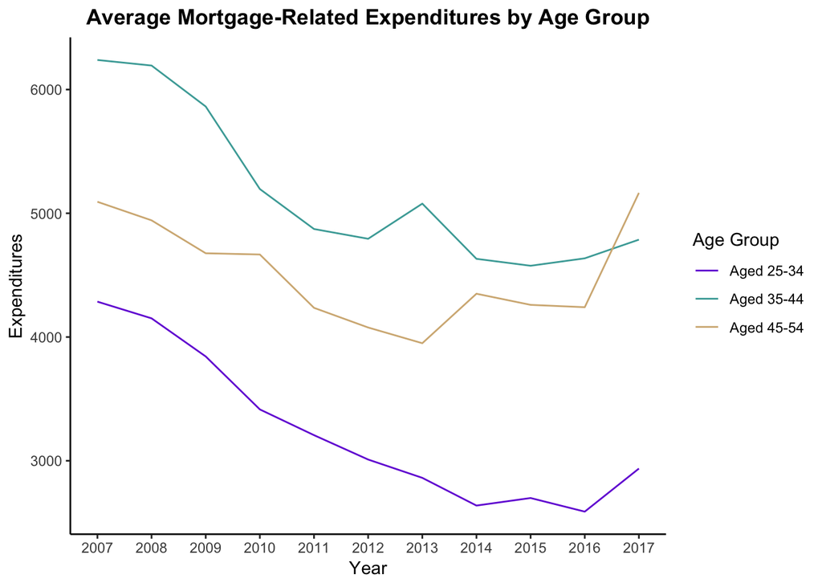

```r
ggplot(mortgages) +
  geom_line(aes(x = Year, y = Value, colour = Age.Group)) +
  theme_classic() + scale_x_continuous(breaks = 2007:2017, labels = unique(mortgages$Year)) +
  scale_colour_manual(name = "Age Group", values = c("#731DD8","#48A9A6","#D4B483")) +
  labs(title = "Average Mortgage-Related Expenditures by Age Group", x = "Year", y = "Expenditures") +
  theme(plot.title = element_text(hjust = 0.5, face = "bold"))
```

The story here matches expectations: on average, Millenials buy significantly less on mortgage-related expenditures than other groups, and their average expenditures in this category have declined over time. Mortgage spending has declined consistently across all age groups, but the decline has been starkest for Millenials. All age groups also experienced growth in these expenditures from 2016-2017, though the growth was largest for individuals aged 45-54.

# Conclusion

The web scraping data show that many industries are affected by declining Millenial spending. My findings suggest that Millenials are reducing spending across many categories of non-essential items. One path forward may be to associate each item with an industry, and the visualize the data by industry. Another method might be to look at the number of times an item is mentioned by the media; this may be an indicator that the spending trend is particularly strong. It’s evident that some of the items may have just been included in articles for sensationalism (I’m thinking of items like “home-cooked meals”), so the latter method may not be a good way to measure how significant a trend is in reality.

The BLS data matches expectations for most of the three categories. On average, Millenials really do spend less on average than other age groups on cereal and mortgages. Is that decreased spending enough to cause those industries to go belly-up? While the actual value of expenditures in these categories is less for Millenials, all age groups tend to show the same trends in average expenditures, so the phenomonena affecting Millenials are likely affecting everyone. I think it would be interesting to look at the microdata for finer categories of products mentioned in the articles.